# Single Cell Network Reconstruction with scMRA

In this Notebook we use scMRA to reconstruct a signaling network of the EGFR-pathway. Therefore we use simulated single-cell (phospho)-protein data of the Orton Model. The data contains measurements of phospho- and total protein for 250 cells and eleven proteins.

```python
import scmra
import pandas as pd
import numpy as np
import seaborn as sns; sns.set_theme()
import matplotlib.pyplot as plt
from IPython.display import display, HTML
import networkx as nx

#read in data
data = pd.read_csv("../data/scData_wildtype.tsv", sep='\t')
```

## Data Preparation

```python
#add a SC-ID
data.index = ["ID."+str(i) for i in range(data.shape[0])]

#calculate input: deviatipon of protein from cell population mean
dat_scaled = ((data - data.median())/data.median()).transpose()

#get active protein deviations (frmo those we infer interaction strengths)
rglob = dat_scaled.loc[[n for n in list(dat_scaled.index) if ("Active" in n)]]
rglob.index = [i.replace("Active", "") for i in rglob.index]

#get total protein deviations: 'natural perturbations'
rtot = dat_scaled.loc[[n for n in list(dat_scaled.index) if ("Tot" in n)]]
rtot.index = [i.replace("Tot", "") for i in rtot.index]

display(rglob.head)
```

```
<bound method NDFrame.head of             ID.0      ID.1      ID.2      ID.3      ID.4      ID.5      ID.6  \
Sos    -0.051155  0.085232  0.008321  0.073530  0.037336  0.077462  0.092302
Ras    -0.076395  0.054095 -0.007728  0.025145  0.028869  0.058157  0.088900
Raf1   -0.103680  0.069777  0.053183  0.041268  0.066881  0.064294  0.005852
Mek    -0.033101 -0.152314 -0.050093 -0.128995  0.069491 -0.148370  0.166537
Erk    -0.106257 -0.177075  0.030958 -0.113891  0.051923 -0.161771  0.092711
P90Rsk -0.129504 -0.117604 -0.007665 -0.074405 -0.126830 -0.019424  0.120107
PI3K    0.142959  0.021876 -0.143707  0.023346  0.029151  0.198616  0.008005
Akt     0.116549 -0.098978 -0.143954 -0.084988  0.046098  0.104219  0.110371
C3G     0.007717 -0.082415 -0.006071 -0.138128  0.056060 -0.083842 -0.024886
Rap1   -0.005878 -0.069144  0.016994 -0.137141  0.027891 -0.114642  0.005731
bRaf    0.072555 -0.084724 -0.030218 -0.107014  0.048830 -0.116599  0.097450

            ID.7      ID.8      ID.9  ...    ID.240    ID.241    ID.242  \
Sos    -0.008603 -0.222532  0.126810  ... -0.094700 -0.237459 -0.100487
Ras     0.004750 -0.215548  0.117134  ... -0.117030 -0.264199 -0.082735
Raf1    0.066933 -0.259652  0.135834  ... -0.178845 -0.324005 -0.072003
Mek     0.058568  0.107128 -0.142194  ...  0.144093  0.070434  0.045346
Erk     0.024951  0.221935 -0.127559  ...  0.143330  0.013953  0.156041
P90Rsk  0.015984  0.237644 -0.188018  ... -0.059097 -0.065432  0.160903
PI3K    0.087303 -0.074450 -0.020944  ... -0.029353 -0.002874  0.065850
Akt    -0.176313  0.044074 -0.082037  ...  0.116220  0.103712 -0.074635
C3G     0.005292  0.115988  0.113998  ...  0.129428  0.128431 -0.017273
Rap1    0.009414  0.123415  0.086880  ...  0.135517  0.103057 -0.037426
bRaf    0.006757  0.086650  0.085719  ...  0.119990  0.073498  0.017430

          ID.243    ID.244    ID.245    ID.246    ID.247    ID.248    ID.249
Sos    -0.036475 -0.165083 -0.107879 -0.035377  0.137442 -0.172961  0.087074
Ras    -0.020628 -0.175497 -0.123056 -0.007759  0.112728 -0.195095  0.052859
Raf1    0.006394 -0.207331 -0.106979 -0.037144  0.126883 -0.212635  0.137019
Mek    -0.002845  0.109314 -0.093608 -0.074491  0.002844  0.118653  0.027718
Erk     0.097090  0.088938 -0.045883 -0.029147  0.009935  0.135879  0.079179
P90Rsk  0.065053  0.084095  0.037934  0.039865 -0.026981  0.207729 -0.072461
PI3K   -0.032113 -0.083988  0.228363 -0.054729  0.055028  0.149363  0.021098
Akt     0.039172 -0.015887 -0.040904  0.200536  0.037683 -0.029558 -0.143577
C3G    -0.081234  0.001695  0.079890 -0.102714 -0.138296  0.202136 -0.082332
Rap1   -0.080556 -0.001542  0.051694 -0.083326 -0.155609  0.199343 -0.076946
bRaf   -0.050971  0.000265  0.014805 -0.022855 -0.099917  0.113333 -0.068884

[11 rows x 250 columns]>
```

## Define Network Sparcity

scMRA penalizes the number of edges in the network with the η-parameter. When the number of edges in the network is not know we recommend to pick a number of edges in the network such that modeling additional interactions would lead to only a marginal reduction in the mean squared error.

```python
%%capture

etaRange = numbers = np.linspace(0.0001, 0.75, 20)
dfEdgeEstimation = pd.DataFrame(columns=['Eta', 'MSE', '#Edge'])
for eta in etaRange:

    #make MRA simulation
    scd = scmra.ScData(rglob=rglob, rtot = rtot)
    p = scmra.ScMraProblem(scd, eta=eta)
    p.cpx.solve()
    result = scmra.ScMraResult(p)

    #store number of edges/ Mean Sqared Error/ penalty
    n_res = np.size(result.residuals_complete) + np.size(result.residuals_incomplete)
    error = np.sum(np.array(np.square(result.residuals_complete)))
    error += np.sum(np.array(np.square(result.residuals_incomplete)))
    error = error/n_res
    edgeNum = result.imap.sum().sum()
    row = {'Eta': [eta], 'MSE': [error], '#Edge': [edgeNum]}
    dfEdgeEstimation = pd.concat([dfEdgeEstimation, pd.DataFrame(row)])
```

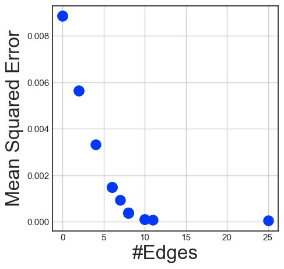

|  | Eta | MSE | #Edge |
| --- | --- | --- | --- |
| 0 | 0.000100 | 0.000058 | 25 |
| 0 | 0.039568 | 0.000079 | 11 |
| 0 | 0.079037 | 0.000118 | 10 |
| 0 | 0.118505 | 0.000118 | 10 |
| 0 | 0.157974 | 0.000379 | 8 |
| 0 | 0.197442 | 0.000379 | 8 |
| 0 | 0.236911 | 0.000379 | 8 |
| 0 | 0.276379 | 0.000379 | 8 |
| 0 | 0.315847 | 0.000379 | 8 |
| 0 | 0.355316 | 0.000379 | 8 |
| 0 | 0.394784 | 0.000379 | 8 |
| 0 | 0.434253 | 0.000931 | 7 |
| 0 | 0.473721 | 0.001495 | 6 |
| 0 | 0.513189 | 0.001495 | 6 |
| 0 | 0.552658 | 0.001495 | 6 |
| 0 | 0.592126 | 0.003341 | 4 |
| 0 | 0.631595 | 0.005650 | 2 |
| 0 | 0.671063 | 0.005650 | 2 |
| 0 | 0.710532 | 0.008861 | 0 |
| 0 | 0.750000 | 0.008861 | 0 |

```python
with plt.style.context("seaborn-whitegrid"):
    plt.rcParams["axes.edgecolor"] = "0.15"
    plt.rcParams["axes.linewidth"]  = 1.25
    f, ax = plt.subplots(figsize=(5, 5))
    wt = ax.scatter(dfEdgeEstimation["#Edge"], dfEdgeEstimation["MSE"], color = "#0138FE", s = 150)
    ax.plot(ls="--", c=".3")
    plt.xlabel('#Edges', size = 24)
    plt.ylabel('Mean Squared Error', size = 24)
    plt.show()

display(dfEdgeEstimation)
```

## Reconstruct the network

Based on the above plot we choose an η-parameter of 0.1 to reconstruct a network with 10 edges as identifying more edges in the network seems to only decrease the MSE marginally. The interaction strenghts between proteins can be retrieved from the 'scMRAResult' class. In traditional MRA the inferred interaction strenghts are termed local response coefficients - opposed to the measurable perturbation induced global response coeeficients. Based on that the 'rloc' variable of the 'scMRAResult' holds a weighted adjacency matrix of the inferred network topology. Here we visualize the resulting network topology and interaction strenght with networkX.

```python
%%capture

#make MRA simulation
eta = 0.1
scd = scmra.ScData(rglob=rglob, rtot = rtot)
p = scmra.ScMraProblem(scd, eta=eta)
p.cpx.solve()
result = scmra.ScMraResult(p)
```

|  | Sos | Ras | Raf1 | Mek | Erk | P90Rsk | PI3K | Akt | C3G | Rap1 | bRaf |
| --- | --- | --- | --- | --- | --- | --- | --- | --- | --- | --- | --- |
| Sos | -1.000000 | 0.0000 | 0.0 | 0.000000 | 0.00000 | -0.798104 | 0.000000 | 0.000000 | 0.000000 | 0.000000 | 0.000000 |
| Ras | 0.997905 | -1.0000 | 0.0 | 0.000000 | 0.00000 | 0.000000 | 0.000000 | 0.000000 | 0.000000 | 0.000000 | 0.000000 |
| Raf1 | 0.000000 | 1.0035 | -1.0 | 0.000000 | 0.00000 | 0.000000 | 0.000000 | -0.401177 | 0.000000 | 0.000000 | 0.000000 |
| Mek | 0.000000 | 0.0000 | 0.0 | -1.000000 | 0.00000 | 0.000000 | 0.000000 | 0.000000 | 0.000000 | 0.000000 | 0.879479 |
| Erk | 0.000000 | 0.0000 | 0.0 | 1.002274 | -1.00000 | 0.000000 | 0.000000 | 0.000000 | 0.000000 | 0.000000 | 0.000000 |
| P90Rsk | 0.000000 | 0.0000 | 0.0 | 0.000000 | 0.93911 | -1.000000 | 0.000000 | 0.000000 | 0.000000 | 0.000000 | 0.000000 |
| PI3K | 0.000000 | 0.0000 | 0.0 | 0.000000 | 0.00000 | 0.000000 | -1.000000 | 0.000000 | 0.000000 | 0.000000 | 0.000000 |
| Akt | 0.000000 | 0.0000 | 0.0 | 0.000000 | 0.00000 | 0.000000 | 0.379765 | -1.000000 | 0.000000 | 0.000000 | 0.000000 |
| C3G | 0.000000 | 0.0000 | 0.0 | 0.000000 | 0.00000 | 0.000000 | 0.000000 | 0.000000 | -1.000000 | 0.000000 | 0.000000 |
| Rap1 | 0.000000 | 0.0000 | 0.0 | 0.000000 | 0.00000 | 0.000000 | 0.000000 | 0.000000 | 1.000372 | -1.000000 | 0.000000 |
| bRaf | 0.000000 | 0.0000 | 0.0 | 0.000000 | 0.00000 | 0.000000 | 0.000000 | 0.000000 | 0.000000 | 0.776643 | -1.000000 |

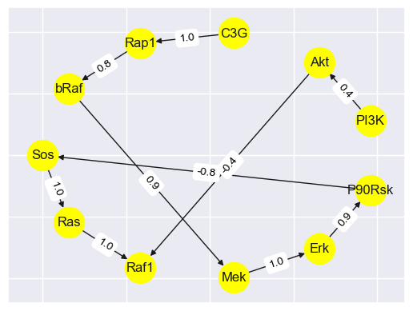

```python
display(result.rloc)

#diagonal rloc entries are per definition -1, replace those with 0 to plot network
A = result.rloc.transpose()
A[A == -1] = 0
G = nx.from_pandas_adjacency(A, create_using=nx.DiGraph)

pos=nx.shell_layout(G)
nx.draw_networkx(G, with_labels=True, node_size = 750, pos = pos, node_color = "yellow")
#create edge labels
edgeLabels = {}
edgeColor = {}
for row_label, row_data in A.iterrows():
    for col_label, value in row_data.items():
        key = (col_label, row_label)
        if(np.abs(value) > 0):
            edgeLabels[key] = round(value,1)

nx.draw_networkx_edge_labels(
    G, pos,
    edge_labels=edgeLabels,
    font_color="black"
)
plt.show()
```

To add additionally perturbations we have to set two variables to match cells to their treatment, and treatments to the corresponding protein that was perturbed:

- cell_annot: dictionary mapping a treatment to the cellIDs that were treated, e.g., {'ctr' : [cell1, cell2], 'EGFRi' : [cell3, cell4], 'ERKi' : [cell5, cell6]}
- tx_annot: dictionary mapping a treatment to the perturbed node, e.g., {'EGFRi': 'EGFR', 'ERKi': 'ERK'}

The names for the cellID, protein, are the same as the ones in 'rglob', 'rtot'.